# msc dissertation

Halleyson Li 200256823

# *Notes*

1. The GitHub repository for this project could access through [here](https://github.com/halleyson/msc-dissertation.git)

# Loading data

Because the original data was not encoded in UFT-8, so after download the original data, has to open it with excel and re-save it with UFT-8 encoded .csv file. But if knit/publish is not required, then this process is not required, but for loading the data (using readr), it has to be read_csv but not read.csv.

```r
library(readr)

pennycook2 <- read_csv("Pennycooketal Study 2.csv")

# Quick check
head(pennycook2)
```

```
## # A tibble: 6 x 351
##   Ô..Condition  Fake  Real Discern CRT_ACC SciKnow   MMS ResponseID ResponseSet
##          <dbl> <dbl> <dbl>   <dbl>   <dbl>   <dbl> <dbl> <chr>      <chr>
## 1            2  5.13  5.33   0.2     0       0.588   4.7 R_3J34Pa6… Default Re…
## 2            1  2.27  2.93   0.667   0.333   0.588   5.3 R_2s6gfRc… Default Re…
## 3            1  1     1      0       0       0.353   4.5 R_3jTm56r… Default Re…
## 4            1  1     1      0       0.333   0.765   2.5 R_1P0Oso5… Default Re…
## 5            1  4.93  4.73  -0.2     0       0.529   5.2 R_1isxtrw… Default Re…
## 6            2  5.73  5.93   0.2     0       0.588   6.3 R_3r0vs6T… Default Re…
## # … with 342 more variables: Name <chr>, ExternalDataReference <lgl>,
## #   Email <lgl>, IPAddress <chr>, Status <dbl>, StartDate <chr>, EndDate <chr>,
## #   Finished <dbl>, rid <chr>, age <dbl>, gender <dbl>, hhi <dbl>,
## #   ethnicity <dbl>, hispanic <dbl>, education <dbl>, political_party <dbl>,
## #   region <dbl>, zip <dbl>, confirmCode <dbl>, Consent <dbl>,
## #   MetaInfo_1_TEXT <chr>, MetaInfo_2_TEXT <chr>, MetaInfo_3_TEXT <chr>,
## #   MetaInfo_4_TEXT <chr>, MetaInfo_5_TEXT <chr>, MetaInfo_6_TEXT <chr>,
## #   MetaInfo_7_TEXT <chr>, SMinst <dbl>, SharingType_1 <dbl>,
## #   SharingType_2 <dbl>, SharingType_3 <dbl>, SharingType_4 <dbl>,
## #   SharingType_6 <dbl>, SharingType_7 <dbl>, SharingType_7_TEXT <chr>,
## #   SocialMedia_1 <dbl>, SocialMedia_2 <dbl>, SocialMedia_3 <dbl>,
## #   SocialMedia_4 <dbl>, SocialMedia_5 <dbl>, SocialMedia_6 <dbl>,
## #   SocialMedia_6_TEXT <chr>, COVID_concern_1 <dbl>, COVID_news <dbl>,
## #   screen1_1 <dbl>, screen1_2 <dbl>, screen1_3 <dbl>, screen1_4 <dbl>,
## #   screen1_5 <dbl>, screen1_6 <dbl>, screen1_7 <dbl>, screen1_8 <dbl>,
## #   screen1_9 <dbl>, screen1_9_TEXT <chr>, AccInst <dbl>, NR_1 <dbl>,
## #   NR_1_2 <dbl>, NR_1_RT_1 <dbl>, NR_1_RT_2 <dbl>, NR_1_RT_3 <dbl>,
## #   NR_1_RT_4 <dbl>, NR_2 <dbl>, NR_2_2 <dbl>, NR_2_RT_1 <dbl>,
## #   NR_2_RT_2 <dbl>, NR_2_RT_3 <dbl>, NR_2_RT_4 <dbl>, NR_3 <dbl>,
## #   NR_3_2 <dbl>, NR_3_RT_1 <dbl>, NR_3_RT_2 <dbl>, NR_3_RT_3 <dbl>,
## #   NR_3_RT_4 <dbl>, NR_4 <dbl>, NR_4_2 <dbl>, NR_4_RT_1 <dbl>,
## #   NR_4_RT_2 <dbl>, NR_4_RT_3 <dbl>, NR_4_RT_4 <dbl>, SMInst.0 <dbl>,
## #   Fake1_RT_1_1 <dbl>, Fake1_RT_2_1 <dbl>, Fake1_RT_3_1 <dbl>,
## #   Fake1_RT_4_1 <dbl>, Fake1_RT_1_2 <dbl>, Fake1_RT_2_2 <dbl>,
## #   Fake1_RT_3_2 <dbl>, Fake1_RT_4_2 <dbl>, Fake1_RT_1_3 <dbl>,
## #   Fake1_RT_2_3 <dbl>, Fake1_RT_3_3 <dbl>, Fake1_RT_4_3 <dbl>,
## #   Fake1_RT_1_4 <dbl>, Fake1_RT_2_4 <dbl>, Fake1_RT_3_4 <dbl>,
## #   Fake1_RT_4_4 <dbl>, Fake1_RT_1_5 <dbl>, Fake1_RT_2_5 <dbl>,
## #   Fake1_RT_3_5 <dbl>, Fake1_RT_4_5 <dbl>, …
```

# General steps to regenerate headline result (study 2)

## data cleaning

```r
# rename columns that contains special characters
colnames(pennycook2)
names(pennycook2)[1] <- "condition"


#remove a participants that did not answer or fail to record any questions

pennycook2 <- pennycook2[!is.na(pennycook2$Fake),]


#data description: condition 1 = control; condition 2 = treatment

#Choose with the column position
library("dplyr")
pennystudy2r1 <- pennycook2 %>%
  dplyr::select(c(1, 210, 211, 212, 213, 214, 215, 216, 217, 218, 219, 220, 221, 222, 223, 224, 225, 226, 227, 228, 229, 230, 231, 232, 233, 234, 235, 236, 237, 238, 239, 2, 3, 4, 57, 60, 250, 252, 284,))

#re-code sharing intentions (fake/real) using the scale midpoint (1-3 = 0, 4-6 = 1)
###(06/08/21 update: realize I could do it after change it from wide to long, then only the column: "measurement" needs to perform the change.)

##Fake
pennystudy2r1$Fake[pennystudy2r1$Fake > 0 & pennystudy2r1$Fake < 4] <- 0
pennystudy2r1$Fake[pennystudy2r1$Fake > 3 & pennystudy2r1$Fake < 7] <- 1
pennystudy2r1$Fake

pennystudy2r1$Fake1_1[pennystudy2r1$Fake1_1 > 0 & pennystudy2r1$Fake1_1 < 4] <- 0
pennystudy2r1$Fake1_1[pennystudy2r1$Fake1_1 > 3 & pennystudy2r1$Fake1_1 < 7] <- 1

pennystudy2r1$Fake1_2[pennystudy2r1$Fake1_2 > 0 & pennystudy2r1$Fake1_2 < 4] <- 0
pennystudy2r1$Fake1_2[pennystudy2r1$Fake1_2 > 3 & pennystudy2r1$Fake1_2 < 7] <- 1

pennystudy2r1$Fake1_3[pennystudy2r1$Fake1_3 > 0 & pennystudy2r1$Fake1_3 < 4] <- 0
pennystudy2r1$Fake1_3[pennystudy2r1$Fake1_3 > 3 & pennystudy2r1$Fake1_3 < 7] <- 1

pennystudy2r1$Fake1_4[pennystudy2r1$Fake1_4 > 0 & pennystudy2r1$Fake1_4 < 4] <- 0
pennystudy2r1$Fake1_4[pennystudy2r1$Fake1_4 > 3 & pennystudy2r1$Fake1_4 < 7] <- 1

pennystudy2r1$Fake1_5[pennystudy2r1$Fake1_5 > 0 & pennystudy2r1$Fake1_5 < 4] <- 0
pennystudy2r1$Fake1_5[pennystudy2r1$Fake1_5 > 3 & pennystudy2r1$Fake1_5 < 7] <- 1

pennystudy2r1$Fake1_6[pennystudy2r1$Fake1_6 > 0 & pennystudy2r1$Fake1_6 < 4] <- 0
pennystudy2r1$Fake1_6[pennystudy2r1$Fake1_6 > 3 & pennystudy2r1$Fake1_6 < 7] <- 1

pennystudy2r1$Fake1_7[pennystudy2r1$Fake1_7 > 0 & pennystudy2r1$Fake1_7 < 4] <- 0
pennystudy2r1$Fake1_7[pennystudy2r1$Fake1_7 > 3 & pennystudy2r1$Fake1_7 < 7] <- 1

pennystudy2r1$Fake1_8[pennystudy2r1$Fake1_8 > 0 & pennystudy2r1$Fake1_8 < 4] <- 0
pennystudy2r1$Fake1_8[pennystudy2r1$Fake1_8 > 3 & pennystudy2r1$Fake1_8 < 7] <- 1

pennystudy2r1$Fake1_9[pennystudy2r1$Fake1_9 > 0 & pennystudy2r1$Fake1_9 < 4] <- 0
pennystudy2r1$Fake1_9[pennystudy2r1$Fake1_9 > 3 & pennystudy2r1$Fake1_9 < 7] <- 1

pennystudy2r1$Fake1_10[pennystudy2r1$Fake1_10 > 0 & pennystudy2r1$Fake1_10 < 4] <- 0
pennystudy2r1$Fake1_10[pennystudy2r1$Fake1_10 > 3 & pennystudy2r1$Fake1_10 < 7] <- 1

pennystudy2r1$Fake1_11[pennystudy2r1$Fake1_11 > 0 & pennystudy2r1$Fake1_11 < 4] <- 0
pennystudy2r1$Fake1_11[pennystudy2r1$Fake1_11 > 3 & pennystudy2r1$Fake1_11 < 7] <- 1

pennystudy2r1$Fake1_12[pennystudy2r1$Fake1_12 > 0 & pennystudy2r1$Fake1_12 < 4] <- 0
pennystudy2r1$Fake1_12[pennystudy2r1$Fake1_12 > 3 & pennystudy2r1$Fake1_12 < 7] <- 1

pennystudy2r1$Fake1_13[pennystudy2r1$Fake1_13 > 0 & pennystudy2r1$Fake1_13 < 4] <- 0
pennystudy2r1$Fake1_13[pennystudy2r1$Fake1_13 > 3 & pennystudy2r1$Fake1_13 < 7] <- 1

pennystudy2r1$Fake1_14[pennystudy2r1$Fake1_14 > 0 & pennystudy2r1$Fake1_14 < 4] <- 0
pennystudy2r1$Fake1_14[pennystudy2r1$Fake1_14 > 3 & pennystudy2r1$Fake1_14 < 7] <- 1

pennystudy2r1$Fake1_15[pennystudy2r1$Fake1_15 > 0 & pennystudy2r1$Fake1_15 < 4] <- 0
pennystudy2r1$Fake1_15[pennystudy2r1$Fake1_15 > 3 & pennystudy2r1$Fake1_15 < 7] <- 1


##Real
pennystudy2r1$Real[pennystudy2r1$Real > 0 & pennystudy2r1$Real < 4] <- 0
pennystudy2r1$Real[pennystudy2r1$Real > 3 & pennystudy2r1$Real < 7] <- 1
pennystudy2r1$Real

pennystudy2r1$Real1_1[pennystudy2r1$Real1_1 > 0 & pennystudy2r1$Real1_1 < 4] <- 0
pennystudy2r1$Real1_1[pennystudy2r1$Real1_1 > 3 & pennystudy2r1$Real1_1 < 7] <- 1

pennystudy2r1$Real1_2[pennystudy2r1$Real1_2 > 0 & pennystudy2r1$Real1_2 < 4] <- 0
pennystudy2r1$Real1_2[pennystudy2r1$Real1_2 > 3 & pennystudy2r1$Real1_2 < 7] <- 1

pennystudy2r1$Real1_3[pennystudy2r1$Real1_3 > 0 & pennystudy2r1$Real1_3 < 4] <- 0
pennystudy2r1$Real1_3[pennystudy2r1$Real1_3 > 3 & pennystudy2r1$Real1_3 < 7] <- 1

pennystudy2r1$Real1_4[pennystudy2r1$Real1_4 > 0 & pennystudy2r1$Real1_4 < 4] <- 0
pennystudy2r1$Real1_4[pennystudy2r1$Real1_4 > 3 & pennystudy2r1$Real1_4 < 7] <- 1

pennystudy2r1$Real1_5[pennystudy2r1$Real1_5 > 0 & pennystudy2r1$Real1_5 < 4] <- 0
pennystudy2r1$Real1_5[pennystudy2r1$Real1_5 > 3 & pennystudy2r1$Real1_5 < 7] <- 1

pennystudy2r1$Real1_6[pennystudy2r1$Real1_6 > 0 & pennystudy2r1$Real1_6 < 4] <- 0
pennystudy2r1$Real1_6[pennystudy2r1$Real1_6 > 3 & pennystudy2r1$Real1_6 < 7] <- 1

pennystudy2r1$Real1_7[pennystudy2r1$Real1_7 > 0 & pennystudy2r1$Real1_7 < 4] <- 0
pennystudy2r1$Real1_7[pennystudy2r1$Real1_7 > 3 & pennystudy2r1$Real1_7 < 7] <- 1

pennystudy2r1$Real1_8[pennystudy2r1$Real1_8 > 0 & pennystudy2r1$Real1_8 < 4] <- 0
pennystudy2r1$Real1_8[pennystudy2r1$Real1_8 > 3 & pennystudy2r1$Real1_8 < 7] <- 1

pennystudy2r1$Real1_9[pennystudy2r1$Real1_9 > 0 & pennystudy2r1$Real1_9 < 4] <- 0
pennystudy2r1$Real1_9[pennystudy2r1$Real1_9 > 3 & pennystudy2r1$Real1_9 < 7] <- 1

pennystudy2r1$Real1_10[pennystudy2r1$Real1_10 > 0 & pennystudy2r1$Real1_10 < 4] <- 0
pennystudy2r1$Real1_10[pennystudy2r1$Real1_10 > 3 & pennystudy2r1$Real1_10 < 7] <- 1

pennystudy2r1$Real1_11[pennystudy2r1$Real1_11 > 0 & pennystudy2r1$Real1_11 < 4] <- 0
pennystudy2r1$Real1_11[pennystudy2r1$Real1_11 > 3 & pennystudy2r1$Real1_11 < 7] <- 1

pennystudy2r1$Real1_12[pennystudy2r1$Real1_12 > 0 & pennystudy2r1$Real1_12 < 4] <- 0
pennystudy2r1$Real1_12[pennystudy2r1$Real1_12 > 3 & pennystudy2r1$Real1_12 < 7] <- 1

pennystudy2r1$Real1_13[pennystudy2r1$Real1_13 > 0 & pennystudy2r1$Real1_13 < 4] <- 0
pennystudy2r1$Real1_13[pennystudy2r1$Real1_13 > 3 & pennystudy2r1$Real1_13 < 7] <- 1

pennystudy2r1$Real1_14[pennystudy2r1$Real1_14 > 0 & pennystudy2r1$Real1_14 < 4] <- 0
pennystudy2r1$Real1_14[pennystudy2r1$Real1_14 > 3 & pennystudy2r1$Real1_14 < 7] <- 1

pennystudy2r1$Real1_15[pennystudy2r1$Real1_15 > 0 & pennystudy2r1$Real1_15 < 4] <- 0
pennystudy2r1$Real1_15[pennystudy2r1$Real1_15 > 3 & pennystudy2r1$Real1_15 < 7] <- 1


#create veracity column (Real - Fake)
pennystudy2r1['veracity']=pennystudy2r1['Real'] - pennystudy2r1['Fake']

#successful screen1 test (result = 2)
pennystudy2r1['screen1']=pennystudy2r1['screen1_4'] + pennystudy2r1['screen1_7']

#successful screen2 test (result = 2)
pennystudy2r1['screen2']=pennystudy2r1['screen2_3'] + pennystudy2r1['screen2_5']

#successful screen3 test (result = 3)
pennystudy2r1['screen3'] = na_if(pennystudy2r1$screen3_2,1)
pennystudy2r1['screen3'] = na_if(pennystudy2r1$screen3,2)
pennystudy2r1['screen3'] = na_if(pennystudy2r1$screen3,4)
pennystudy2r1['screen3'] = na_if(pennystudy2r1$screen3,5)
#check if screen 3 successful
mean(pennystudy2r1$screen3, na.rm = TRUE)

#re-code screen test: replace 2 and 3 to 1
pennystudy2r1["screen1"][pennystudy2r1["screen1"] == 2] <- 1
pennystudy2r1["screen2"][pennystudy2r1["screen2"] == 2] <- 1
pennystudy2r1["screen3"][pennystudy2r1["screen3"] == 3] <- 1

#replace NA to 0 in screen 1,2,3

pennystudy2r1[c("screen1","screen2","screen3")][is.na(pennystudy2r1[c("screen1","screen2","screen3")])] <- 0

#create dummy column, add screen 1,2,3 together. Screen = 3 indicate success in all attention check
pennystudy2r1['dummycheck']=pennystudy2r1['screen1'] + pennystudy2r1['screen2'] + pennystudy2r1['screen3']


#re-code condition control = 0 treatment = 1
pennystudy2r1["condition"][pennystudy2r1["condition"] == 1] <- 0
pennystudy2r1["condition"][pennystudy2r1["condition"] == 2] <- 1

#like the researcher did, change data frame from wide to long
##first drop unnecessary column
colnames(pennystudy2r1)

pennys2r1long <- subset(pennystudy2r1, select = c(1,2,3,4,5,6,7,8,9,10,11,12,13,14,15,16,17,18,19,20,21,22,23,24,25,26,27,28,29,30,31,32,33,34,40,44))

##Add ID column
pennys2r1long <- tibble::rowid_to_column(pennys2r1long, "ID")

## change from wide to long
library(tidyr)

keycol <- "newstype"
valuecol <- "measurement"
gathercols <- c("Fake1_1","Fake1_2","Fake1_3","Fake1_4","Fake1_5","Fake1_6","Fake1_7","Fake1_8","Fake1_9","Fake1_10","Fake1_11","Fake1_12","Fake1_13","Fake1_14","Fake1_15","Real1_1","Real1_2","Real1_3","Real1_4","Real1_5","Real1_6","Real1_7","Real1_8","Real1_9","Real1_10","Real1_11","Real1_12","Real1_13","Real1_14","Real1_15")

pennys2r1long <- gather_(pennys2r1long, keycol, valuecol, gathercols)

##no idea why it doesn't show condition column (control vs treatment) so I merge original condition to the new one

merge(pennystudy2r1, pennys2r1long, by.x='condition', by.y='ID')

##organize data by ID, then reorder the column
pennys2r1long <- pennys2r1long[order(pennys2r1long$ID),]

pennys2r1long <- pennys2r1long[, c(1, 2, 8, 9, 7, 4, 3, 6, 5)]

##rename real and fake to avereal and avefake, change dummycheck to attentioncheck to make it clear

names(pennys2r1long)[6] <- "Real_ave"
names(pennys2r1long)[7] <- "Fake_ave"
names(pennys2r1long)[5] <- "attentioncheck"

##create a headline veracity column, fake news items code as 0, real news items code as 1

pennys2r1long <- pennys2r1long %>%
  mutate(headlineveracity = case_when(
    startsWith(newstype, "R") ~ "1",
    startsWith(newstype, "F") ~ "0"
    ))

##realise that original researcher exclude the observation with answer contains na, thus the obs needs to minus 23 to match original obs 25,627

pennys2r1long_nona <- pennys2r1long[!is.na(pennys2r1long$measurement),]

##separating the data based on number of successful attention check

### attention check above and equal to 1
pennys2r1longa1 <- subset(pennys2r1long, attentioncheck %in% c("1","2","3"))

### attention check above and equal to 2
pennys2r1longa2 <- subset(pennys2r1long, attentioncheck %in% c("2","3"))

### attention check equal to 3
pennys2r1longa3 <- subset(pennys2r1long, attentioncheck %in% c("3"))


###find out the number of participants (obs) for each attention check level (use it to compare with No of participants in Table S5).

No.participantsa1 <- subset(pennystudy2r1, dummycheck %in% c("1","2","3"))
No.participantsa2 <- subset(pennystudy2r1, dummycheck %in% c("2","3"))
No.participantsa3 <- subset(pennystudy2r1, dummycheck %in% c("3"))
```

## relase I should not dichotomise the scale as it loses info and reduces the power.

```r
#recreate a data frame that does not rescale the data to either 0,1 but from 0 to 1,so divided each value by rating = (rating - 1)/5

pennystudy2r1nodi <- pennycook2 %>%
 dplyr::select (c(1, 210, 211, 212, 213, 214, 215, 216, 217, 218, 219, 220, 221, 222, 223, 224, 225, 226, 227, 228, 229, 230, 231, 232, 233, 234, 235, 236, 237, 238, 239, 2, 3, 4, 57, 60, 250, 252, 284,))


#successful screen1 test (result = 2)
pennystudy2r1nodi['screen1']=pennystudy2r1nodi['screen1_4'] + pennystudy2r1nodi['screen1_7']

#successful screen2 test (result = 2)
pennystudy2r1nodi['screen2']=pennystudy2r1nodi['screen2_3'] + pennystudy2r1nodi['screen2_5']

#successful screen3 test (result = 3)
pennystudy2r1nodi['screen3'] = na_if(pennystudy2r1nodi$screen3_2,1)
pennystudy2r1nodi['screen3'] = na_if(pennystudy2r1nodi$screen3,2)
pennystudy2r1nodi['screen3'] = na_if(pennystudy2r1nodi$screen3,4)
pennystudy2r1nodi['screen3'] = na_if(pennystudy2r1nodi$screen3,5)
#check if screen 3 successful
mean(pennystudy2r1nodi$screen3, na.rm = TRUE)

#re-code screen test: replace 2 and 3 to 1
pennystudy2r1nodi["screen1"][pennystudy2r1nodi["screen1"] == 2] <- 1
pennystudy2r1nodi["screen2"][pennystudy2r1nodi["screen2"] == 2] <- 1
pennystudy2r1nodi["screen3"][pennystudy2r1nodi["screen3"] == 3] <- 1

#re-code condition control = 0 treatment = 1
pennystudy2r1nodi["condition"][pennystudy2r1nodi["condition"] == 1] <- 0
pennystudy2r1nodi["condition"][pennystudy2r1nodi["condition"] == 2] <- 1

#replace NA to 0 in screen 1,2,3

pennystudy2r1nodi[c("screen1","screen2","screen3")][is.na(pennystudy2r1nodi[c("screen1","screen2","screen3")])] <- 0

#create dummy column, add screen 1,2,3 together. Screen = 3 indicate success in all attention check
pennystudy2r1nodi['dummycheck']=pennystudy2r1nodi['screen1'] + pennystudy2r1nodi['screen2'] + pennystudy2r1nodi['screen3']


#like the researcher did, change data frame from wide to long
##first drop unnecessary column
colnames(pennystudy2r1nodi)

pennys2r1longnodi <- subset(pennystudy2r1nodi, select = c(1,2,3,4,5,6,7,8,9,10,11,12,13,14,15,16,17,18,19,20,21,22,23,24,25,26,27,28,29,30,31,32,33,34,43))

##Add ID column
pennys2r1longnodi <- tibble::rowid_to_column(pennys2r1longnodi, "ID")

## change from wide to long
library(tidyr)

keycol <- "newstype"
valuecol <- "measurement"
gathercols <- c("Fake1_1","Fake1_2","Fake1_3","Fake1_4","Fake1_5","Fake1_6","Fake1_7","Fake1_8","Fake1_9","Fake1_10","Fake1_11","Fake1_12","Fake1_13","Fake1_14","Fake1_15","Real1_1","Real1_2","Real1_3","Real1_4","Real1_5","Real1_6","Real1_7","Real1_8","Real1_9","Real1_10","Real1_11","Real1_12","Real1_13","Real1_14","Real1_15")

pennys2r1longnodi <- gather_(pennys2r1longnodi, keycol, valuecol, gathercols)

## I merge original condition to the new one

merge(pennystudy2r1nodi, pennys2r1longnodi, by.x='condition', by.y='ID')

##organize data by ID, then reorder the column
pennys2r1longnodi <- pennys2r1longnodi[order(pennys2r1longnodi$ID),]

pennys2r1longnodi <- pennys2r1longnodi[, c(1, 2, 7, 8, 6, 5, 4, 3)]

##change dummycheck to attentioncheck to make it clear

names(pennys2r1longnodi)[5] <- "attentioncheck"

##create a headline veracity column, fake news items code as 0, real news items code as 1

pennys2r1longnodi <- pennys2r1longnodi %>%
  mutate(headlineveracity = case_when(
    startsWith(newstype, "R") ~ "1",
    startsWith(newstype, "F") ~ "0"
    ))

##recode the measurement column

pennys2r1longnodi <- transform(pennys2r1longnodi, rescale = ave(measurement, condition, FUN = function(x) paste0((x-1)/5)))

##realise that original researcher exclude the observation with answer contains na, thus the obs needs to minus 23 to match original obs 25,627

pennys2r1longnodi_nona <- pennys2r1longnodi[!is.na(pennys2r1longnodi$measurement),]

##create a new column that recode item number from fake and real to 1-30, with 1-15 indicate each fake items, 16-30 indicate each real items, need it for clustering robust standard errors.

pennys2r1longnodi_nona <- within(pennys2r1longnodi_nona,{
  item_id <- NA
  item_id[newstype == "Fake1_1"] <- 1
  item_id[newstype == "Fake1_2"] <- 2
  item_id[newstype == "Fake1_3"] <- 3
  item_id[newstype == "Fake1_4"] <- 4
  item_id[newstype == "Fake1_5"] <- 5
  item_id[newstype == "Fake1_6"] <- 6
  item_id[newstype == "Fake1_7"] <- 7
  item_id[newstype == "Fake1_8"] <- 8
  item_id[newstype == "Fake1_9"] <- 9
  item_id[newstype == "Fake1_10"] <- 10
  item_id[newstype == "Fake1_11"] <- 11
  item_id[newstype == "Fake1_12"] <- 12
  item_id[newstype == "Fake1_13"] <- 13
  item_id[newstype == "Fake1_14"] <- 14
  item_id[newstype == "Fake1_15"] <- 15
  item_id[newstype == "Real1_1"] <- 16
  item_id[newstype == "Real1_2"] <- 17
  item_id[newstype == "Real1_3"] <- 18
  item_id[newstype == "Real1_4"] <- 19
  item_id[newstype == "Real1_5"] <- 20
  item_id[newstype == "Real1_6"] <- 21
  item_id[newstype == "Real1_7"] <- 22
  item_id[newstype == "Real1_8"] <- 23
  item_id[newstype == "Real1_9"] <- 24
  item_id[newstype == "Real1_10"] <- 25
  item_id[newstype == "Real1_11"] <- 26
  item_id[newstype == "Real1_12"] <- 27
  item_id[newstype == "Real1_13"] <- 28
  item_id[newstype == "Real1_14"] <- 29
  item_id[newstype == "Real1_15"] <- 30})




##subset based on attetnion check
attention1nodi <- subset(pennys2r1longnodi_nona, attentioncheck %in% c("1","2","3"))
attention2nodi <- subset(pennys2r1longnodi_nona, attentioncheck %in% c("2","3"))
attention3nodi <- subset(pennys2r1longnodi_nona, attentioncheck %in% c("3"))
```

## reproduction of results (interaction between headline veracity and treatment)

### without considering attention check

```r
library(lmtest)
library(stargazer)
library(sandwich)


lm1 <- lm(rescale ~ headlineveracity + headlineveracity*condition, data = pennys2r1longnodi_nona)
summary(lm1)
```

```
##
## Call:
## lm(formula = rescale ~ headlineveracity + headlineveracity *
##     condition, data = pennys2r1longnodi_nona)
##
## Residuals:
##      Min       1Q   Median       3Q      Max
## -0.52385 -0.46906  0.07615  0.32955  0.53094
##
## Coefficients:
##                             Estimate Std. Error t value Pr(>|t|)
## (Intercept)                 0.469062   0.004715  99.476  < 2e-16 ***
## headlineveracity1           0.019104   0.006669   2.864 0.004181 **
## condition                   0.001386   0.006664   0.208 0.835208
## headlineveracity1:condition 0.034301   0.009426   3.639 0.000274 ***
## ---
## Signif. codes:  0 '***' 0.001 '**' 0.01 '*' 0.05 '.' 0.1 ' ' 1
##
## Residual standard error: 0.3772 on 25623 degrees of freedom
## Multiple R-squared:  0.003421,   Adjusted R-squared:  0.003304
## F-statistic: 29.32 on 3 and 25623 DF,  p-value: < 2.2e-16
```

```r
stargazer(lm1, type='text')
```

```
##
## =======================================================
##                                 Dependent variable:
##                             ---------------------------
##                                       rescale
## -------------------------------------------------------
## headlineveracity1                    0.019***
##                                       (0.007)
##
## condition                              0.001
##                                       (0.007)
##
## headlineveracity1:condition          0.034***
##                                       (0.009)
##
## Constant                             0.469***
##                                       (0.005)
##
## -------------------------------------------------------
## Observations                          25,627
## R2                                     0.003
## Adjusted R2                            0.003
## Residual Std. Error             0.377 (df = 25623)
## F Statistic                  29.320*** (df = 3; 25623)
## =======================================================
## Note:                       *p<0.1; **p<0.05; ***p<0.01
```

```r
coeftest(lm1, vcov = vcovCL, cluster = ~ ID + item_id)
```

```
##
## t test of coefficients:
##
##                              Estimate Std. Error t value  Pr(>|t|)
## (Intercept)                 0.4690625  0.0176918 26.5129 < 2.2e-16 ***
## headlineveracity1           0.0191038  0.0160943  1.1870    0.2352
## condition                   0.0013864  0.0201727  0.0687    0.9452
## headlineveracity1:condition 0.0343014  0.0081118  4.2286  2.36e-05 ***
## ---
## Signif. codes:  0 '***' 0.001 '**' 0.01 '*' 0.05 '.' 0.1 ' ' 1
```

```r
#calculate the effect size cohen's d
##since they need to compare true vs false headline in different condition, thus, create a new data frame that only contain treatment and control with the attention check above and equal to 2, as stated in the research

library(effsize)

##change headlineveracity and rescale to numeric
pennys2r1longnodi_nona <- transform(pennys2r1longnodi_nona,
                   headlineveracity = as.numeric(headlineveracity),
                   rescale = as.numeric(rescale))

#check the class
sapply(pennys2r1longnodi_nona,mode)
```

```
##               ID        condition         newstype      measurement
##        "numeric"        "numeric"      "character"        "numeric"
##   attentioncheck          Discern             Real             Fake
##        "numeric"        "numeric"        "numeric"        "numeric"
## headlineveracity          rescale          item_id
##        "numeric"        "numeric"        "numeric"
```

```r
#subset the table based on condition
pennys2nodicohenc <- subset(pennys2r1longnodi_nona, condition %in% c("0"))
pennys2nodicohent <- subset(pennys2r1longnodi_nona, condition %in% c("1"))

#condition vs measurement effect size, using participants' average measurement.
cohen.d(pennys2nodicohent$Real,pennys2nodicohent$Fake, na.rm = TRUE)
```

```
##
## Cohen's d
##
## d estimate: 0.1827776 (negligible)
## 95 percent confidence interval:
##     lower     upper
## 0.1582545 0.2073007
```

```r
cohen.d(pennys2nodicohenc$Real,pennys2nodicohenc$Fake, na.rm = TRUE)
```

```
##
## Cohen's d
##
## d estimate: 0.06343206 (negligible)
## 95 percent confidence interval:
##      lower      upper
## 0.03892232 0.08794180
```

```r
#Robustness for different levels of attentiveness
##attention above 1
lm2 <- lm(rescale ~ headlineveracity + headlineveracity*condition, data = attention1nodi)
summary(lm2)
```

```
##
## Call:
## lm(formula = rescale ~ headlineveracity + headlineveracity *
##     condition, data = attention1nodi)
##
## Residuals:
##      Min       1Q   Median       3Q      Max
## -0.52024 -0.46537  0.07976  0.33140  0.53463
##
## Coefficients:
##                              Estimate Std. Error t value Pr(>|t|)
## (Intercept)                  0.468599   0.004782  97.999  < 2e-16 ***
## headlineveracity1            0.021453   0.006763   3.172 0.001516 **
## condition                   -0.003227   0.006734  -0.479 0.631735
## headlineveracity1:condition  0.033418   0.009524   3.509 0.000451 ***
## ---
## Signif. codes:  0 '***' 0.001 '**' 0.01 '*' 0.05 '.' 0.1 ' ' 1
##
## Residual standard error: 0.3758 on 24903 degrees of freedom
## Multiple R-squared:  0.003403,   Adjusted R-squared:  0.003283
## F-statistic: 28.34 on 3 and 24903 DF,  p-value: < 2.2e-16
```

```r
stargazer(lm2, type='text')
```

```
##
## =======================================================
##                                 Dependent variable:
##                             ---------------------------
##                                       rescale
## -------------------------------------------------------
## headlineveracity1                    0.021***
##                                       (0.007)
##
## condition                             -0.003
##                                       (0.007)
##
## headlineveracity1:condition          0.033***
##                                       (0.010)
##
## Constant                             0.469***
##                                       (0.005)
##
## -------------------------------------------------------
## Observations                          24,907
## R2                                     0.003
## Adjusted R2                            0.003
## Residual Std. Error             0.376 (df = 24903)
## F Statistic                  28.344*** (df = 3; 24903)
## =======================================================
## Note:                       *p<0.1; **p<0.05; ***p<0.01
```

```r
coeftest(lm2, vcov = vcovCL, cluster = ~ ID + item_id)
```

```
##
## t test of coefficients:
##
##                               Estimate Std. Error t value  Pr(>|t|)
## (Intercept)                  0.4685992  0.0178224 26.2927 < 2.2e-16 ***
## headlineveracity1            0.0214527  0.0161788  1.3260    0.1849
## condition                   -0.0032274  0.0203217 -0.1588    0.8738
## headlineveracity1:condition  0.0334177  0.0082896  4.0313 5.564e-05 ***
## ---
## Signif. codes:  0 '***' 0.001 '**' 0.01 '*' 0.05 '.' 0.1 ' ' 1
```

```r
##attention above 2
lm3 <- lm(rescale ~ headlineveracity + headlineveracity*condition, data = attention2nodi)
summary(lm3)
```

```
##
## Call:
## lm(formula = rescale ~ headlineveracity + headlineveracity *
##     condition, data = attention2nodi)
##
## Residuals:
##     Min      1Q  Median      3Q     Max
## -0.4979 -0.4292 -0.0292  0.3308  0.5708
##
## Coefficients:
##                              Estimate Std. Error t value Pr(>|t|)
## (Intercept)                  0.442994   0.005376  82.406  < 2e-16 ***
## headlineveracity1            0.026196   0.007604   3.445 0.000572 ***
## condition                   -0.013791   0.007668  -1.799 0.072102 .
## headlineveracity1:condition  0.042517   0.010845   3.920 8.87e-05 ***
## ---
## Signif. codes:  0 '***' 0.001 '**' 0.01 '*' 0.05 '.' 0.1 ' ' 1
##
## Residual standard error: 0.377 on 19331 degrees of freedom
## Multiple R-squared:  0.004773,   Adjusted R-squared:  0.004619
## F-statistic:  30.9 on 3 and 19331 DF,  p-value: < 2.2e-16
```

```r
stargazer(lm3, type='text')
```

```
##
## =======================================================
##                                 Dependent variable:
##                             ---------------------------
##                                       rescale
## -------------------------------------------------------
## headlineveracity1                    0.026***
##                                       (0.008)
##
## condition                             -0.014*
##                                       (0.008)
##
## headlineveracity1:condition          0.043***
##                                       (0.011)
##
## Constant                             0.443***
##                                       (0.005)
##
## -------------------------------------------------------
## Observations                          19,335
## R2                                     0.005
## Adjusted R2                            0.005
## Residual Std. Error             0.377 (df = 19331)
## F Statistic                  30.905*** (df = 3; 19331)
## =======================================================
## Note:                       *p<0.1; **p<0.05; ***p<0.01
```

```r
coeftest(lm3, vcov = vcovCL, cluster = ~ ID + item_id)
```

```
##
## t test of coefficients:
##
##                              Estimate Std. Error t value Pr(>|t|)
## (Intercept)                  0.442994   0.019782 22.3938  < 2e-16 ***
## headlineveracity1            0.026196   0.017568  1.4911   0.1359
## condition                   -0.013791   0.022845 -0.6037   0.5461
## headlineveracity1:condition  0.042517   0.010085  4.2158  2.5e-05 ***
## ---
## Signif. codes:  0 '***' 0.001 '**' 0.01 '*' 0.05 '.' 0.1 ' ' 1
```

```r
##attention all 3
lm4 <- lm(rescale ~ headlineveracity + headlineveracity*condition, data = attention3nodi)
summary(lm4)
```

```
##
## Call:
## lm(formula = rescale ~ headlineveracity + headlineveracity *
##     condition, data = attention3nodi)
##
## Residuals:
##     Min      1Q  Median      3Q     Max
## -0.4915 -0.4373  0.1085  0.3302  0.5627
##
## Coefficients:
##                              Estimate Std. Error t value Pr(>|t|)
## (Intercept)                  0.469843   0.009133  51.444   <2e-16 ***
## headlineveracity1            0.021627   0.012920   1.674   0.0942 .
## condition                   -0.032510   0.013176  -2.467   0.0136 *
## headlineveracity1:condition  0.030912   0.018637   1.659   0.0972 .
## ---
## Signif. codes:  0 '***' 0.001 '**' 0.01 '*' 0.05 '.' 0.1 ' ' 1
##
## Residual standard error: 0.3858 on 6861 degrees of freedom
## Multiple R-squared:  0.003117,   Adjusted R-squared:  0.002681
## F-statistic:  7.15 on 3 and 6861 DF,  p-value: 8.614e-05
```

```r
stargazer(lm4, type='text')
```

```
##
## =======================================================
##                                 Dependent variable:
##                             ---------------------------
##                                       rescale
## -------------------------------------------------------
## headlineveracity1                     0.022*
##                                       (0.013)
##
## condition                            -0.033**
##                                       (0.013)
##
## headlineveracity1:condition           0.031*
##                                       (0.019)
##
## Constant                             0.470***
##                                       (0.009)
##
## -------------------------------------------------------
## Observations                           6,865
## R2                                     0.003
## Adjusted R2                            0.003
## Residual Std. Error              0.386 (df = 6861)
## F Statistic                   7.150*** (df = 3; 6861)
## =======================================================
## Note:                       *p<0.1; **p<0.05; ***p<0.01
```

```r
coeftest(lm4, vcov = vcovCL, cluster = ~ ID + item_id)
```

```
##
## t test of coefficients:
##
##                              Estimate Std. Error t value Pr(>|t|)
## (Intercept)                  0.469843   0.031023 15.1447  < 2e-16 ***
## headlineveracity1            0.021627   0.023140  0.9346  0.35001
## condition                   -0.032510   0.040186 -0.8090  0.41856
## headlineveracity1:condition  0.030912   0.016511  1.8722  0.06122 .
## ---
## Signif. codes:  0 '***' 0.001 '**' 0.01 '*' 0.05 '.' 0.1 ' ' 1
```

## reproduction of figure 2 (without considering attention check)

### graph: including all

```r
library(ggplot2)
library(DescTools)

#create a table contain mean and CI for each headline veracity in each condition
z <- with(pennys2r1long_nona,
          aggregate(measurement, list(condition, headlineveracity), MeanCI))
z <- xtabs(x ~ Group.1 + Group.2, z)

z = data.frame(z)

#check the results with equation I know for sure
dummy <- aggregate(measurement~condition+headlineveracity, data = pennys2r1long_nona, FUN = mean)

#reshape the graph
z1 <- subset(z, Var3 %in% c("mean"))
z2 <- subset(z, Var3 %in% c("lwr.ci"))
z3 <- subset(z, Var3 %in% c("upr.ci"))

zsummary <- cbind(z1,z2$Freq,z3$Freq)


zsummary <- zsummary %>%
  dplyr::select (c(1, 2, 4, 5, 6))


names(zsummary)[1] <- "condition"
names(zsummary)[2] <- "headlineveracity"
names(zsummary)[3] <- "percent"
names(zsummary)[4] <- "lowci"
names(zsummary)[5] <- "upci"

#change the value to %
zsummary$percent <- zsummary$percent*100
zsummary$lowci <- zsummary$lowci*100
zsummary$upci <- zsummary$upci*100
str(zsummary)
```

```
## 'data.frame':    4 obs. of  5 variables:
##  $ condition       : Factor w/ 2 levels "0","1": 1 2 1 2
##  $ headlineveracity: Factor w/ 2 levels "0","1": 1 1 2 2
##  $ percent         : num  49.3 48.9 51.9 56.5
##  $ lowci           : num  48 47.7 50.6 55.3
##  $ upci            : num  50.5 50.1 53.1 57.7
```

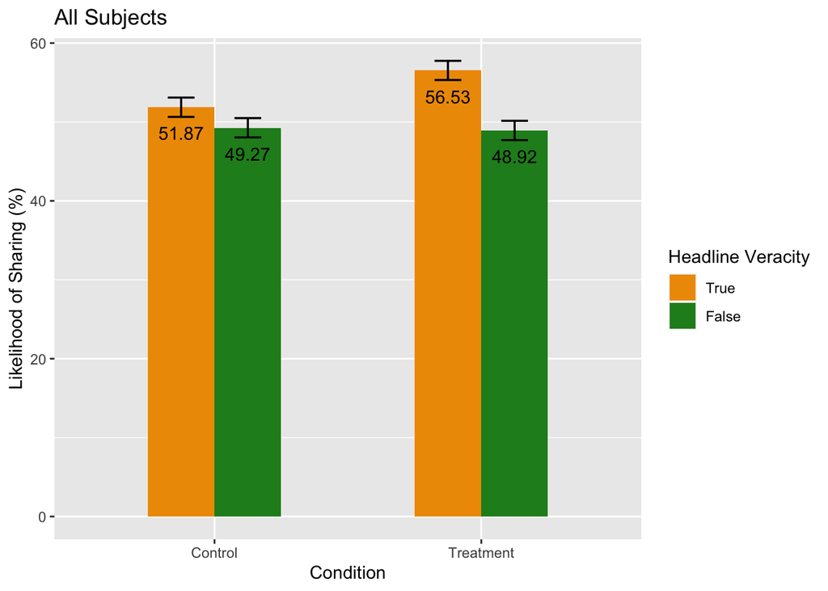

```r
#plot the graph with error bar indicate CI

ggplot(zsummary, aes(x = condition, y = percent, fill = forcats::fct_rev(headlineveracity))) +
  geom_bar(stat = 'identity',position = 'dodge',width = 0.5) +
  geom_text(
    aes(label = sprintf("%.2f",percent)), vjust = 2.5, position = position_dodge(0.5)) +
  xlab("Condition") +
  ylab("Likelihood of Sharing (%)") +
  scale_x_discrete(labels= c("0"="Control","1"="Treatment"))+
  scale_fill_manual(values = c("orange2","forestgreen"), name = "Headline Veracity", labels = c("True", "False")) + labs(title = "All Subjects") +
  geom_errorbar(aes(ymin = lowci, ymax = upci,width = 0.2),position = position_dodge(0.5), size = 0.6)
```

```r
##tips: forcats::fct_rev() is to reverse the order, use scale_fill_manual(values = to change colour

ggsave("All Subjects bar chart.png")
```

##Try something new, see if it makes the results better

###Ordinal logistic regression (best to apply when using likert scale)

```r
#Ordinal logistic regression


library(ordinal)
library(ggeffects)
library(ggrepel)

## All subjects
ordinaldata <- pennys2r1longnodi_nona

str(ordinaldata)
```

```
## 'data.frame':    25627 obs. of  11 variables:
##  $ ID              : int  1 1 1 1 1 1 1 1 1 1 ...
##  $ condition       : num  1 1 1 1 1 1 1 1 1 1 ...
##  $ newstype        : chr  "Fake1_1" "Fake1_2" "Fake1_3" "Fake1_4" ...
##  $ measurement     : num  5 5 6 6 5 5 5 5 4 5 ...
##  $ attentioncheck  : num  1 1 1 1 1 1 1 1 1 1 ...
##  $ Discern         : num  0.2 0.2 0.2 0.2 0.2 0.2 0.2 0.2 0.2 0.2 ...
##  $ Real            : num  5.33 5.33 5.33 5.33 5.33 ...
##  $ Fake            : num  5.13 5.13 5.13 5.13 5.13 ...
##  $ headlineveracity: num  0 0 0 0 0 0 0 0 0 0 ...
##  $ rescale         : num  0.8 0.8 1 1 0.8 0.8 0.8 0.8 0.6 0.8 ...
##  $ item_id         : num  1 2 3 4 5 6 7 8 9 10 ...
```

```r
ordinaldata$measurement <- as.factor(ordinaldata$measurement)


ordinal <- clm(measurement ~ condition + condition*headlineveracity, data = ordinaldata, link = "logit")

summary(ordinal)
```

```
## formula: measurement ~ condition + condition * headlineveracity
## data:    ordinaldata
##
##  link  threshold nobs  logLik    AIC      niter max.grad cond.H
##  logit flexible  25627 -44558.88 89133.76 7(0)  4.43e-10 2.0e+02
##
## Coefficients:
##                            Estimate Std. Error z value Pr(>|z|)
## condition                   0.01001    0.03156   0.317 0.751205
## headlineveracity            0.08789    0.03133   2.805 0.005029 **
## condition:headlineveracity  0.14863    0.04414   3.367 0.000759 ***
## ---
## Signif. codes:  0 '***' 0.001 '**' 0.01 '*' 0.05 '.' 0.1 ' ' 1
##
## Threshold coefficients:
##     Estimate Std. Error z value
## 1|2 -0.93107    0.02390 -38.953
## 2|3 -0.44221    0.02331 -18.973
## 3|4  0.02267    0.02315   0.979
## 4|5  0.66735    0.02351  28.382
## 5|6  1.47811    0.02508  58.932
```

```r
exp(coef(ordinal))
```

```
##                        1|2                        2|3
##                  0.3941337                  0.6426170
##                        3|4                        4|5
##                  1.0229313                  1.9490692
##                        5|6                  condition
##                  4.3846318                  1.0100553
##           headlineveracity condition:headlineveracity
##                  1.0918716                  1.1602409
```

```r
ggpredict_ordinal <- ggpredict(ordinal, terms = c("condition","headlineveracity"))
ggpredict_ordinaldata = data.frame(ggpredict_ordinal)

ggpredict_ordinal
```

```
## # Predicted probabilities of measurement
##
## # Response Level = 1
## # headlineveracity = 0
##
## condition | Predicted |       95% CI
## ------------------------------------
##         0 |      0.28 | [0.27, 0.29]
##         1 |      0.28 | [0.27, 0.29]
##
## # Response Level = 2
## # headlineveracity = 0
##
## condition | Predicted |       95% CI
## ------------------------------------
##         0 |      0.11 | [0.10, 0.11]
##         1 |      0.11 | [0.10, 0.11]
##
## # Response Level = 3
## # headlineveracity = 0
##
## condition | Predicted |       95% CI
## ------------------------------------
##         0 |      0.11 | [0.11, 0.12]
##         1 |      0.11 | [0.11, 0.12]
##
## # Response Level = 4
## # headlineveracity = 0
##
## condition | Predicted |       95% CI
## ------------------------------------
##         0 |      0.16 | [0.15, 0.16]
##         1 |      0.16 | [0.15, 0.16]
##
## # Response Level = 5
## # headlineveracity = 0
##
## condition | Predicted |       95% CI
## ------------------------------------
##         0 |      0.15 | [0.15, 0.16]
```

[output cut: 42 more lines]

```
## # Response Level = 5
## # headlineveracity = 1
##
## condition | Predicted |       95% CI
## ------------------------------------
##         0 |      0.16 | [0.15, 0.17]
##         1 |      0.17 | [0.16, 0.18]
##
## # Response Level = 6
## # headlineveracity = 1
##
## condition | Predicted |       95% CI
## ------------------------------------
##         0 |      0.20 | [0.19, 0.21]
##         1 |      0.23 | [0.22, 0.24]
```

```r
str(ggpredict_ordinaldata)
```

```
## 'data.frame':    24 obs. of  6 variables:
##  $ x             : num  0 0 0 0 0 0 0 0 0 0 ...
##  $ predicted     : num  0.283 0.109 0.114 0.155 0.153 ...
##  $ conf.low      : num  0.272 0.104 0.11 0.15 0.148 ...
##  $ conf.high     : num  0.294 0.113 0.119 0.16 0.159 ...
##  $ response.level: int  1 2 3 4 5 6 1 2 3 4 ...
##  $ group         : Factor w/ 2 levels "0","1": 1 1 1 1 1 1 2 2 2 2 ...
```

```r
ggpredict_ordinaldata$x = factor(ggpredict_ordinaldata$x)
levels(ggpredict_ordinaldata$x) = c("False", "True")
colnames(ggpredict_ordinaldata)[c(1,5,6)] =c("Headlineveracity", "Rating", "group")
levels(ggpredict_ordinaldata$group) = c("Control", "Treatment")
ggpredict_ordinaldata
```

```
##    Headlineveracity  predicted   conf.low conf.high Rating     group
## 1             False 0.28270867 0.27197203 0.2936982      1   Control
## 2             False 0.10850668 0.10389652 0.1132955      2   Control
## 3             False 0.11445248 0.11000529 0.1190554      3   Control
## 4             False 0.15524213 0.15014480 0.1604798      4   Control
## 5             False 0.15337632 0.14757040 0.1593680      5   Control
## 6             False 0.18571372 0.17736192 0.1943659      6   Control
## 7             False 0.26523034 0.25501221 0.2757064      1 Treatment
## 8             False 0.10526330 0.10075295 0.1099509      2 Treatment
## 9             False 0.11320689 0.10878547 0.1177843      3 Treatment
## 10            False 0.15724230 0.15213929 0.1624837      4 Treatment
## 11            False 0.15968331 0.15383813 0.1657071      5 Treatment
## 12            False 0.19937386 0.19072404 0.2083150      6 Treatment
## 13             True 0.28068421 0.27004176 0.2915786      1   Control
## 14             True 0.10815088 0.10355437 0.1129257      2   Control
## 15             True 0.11433167 0.10988534 0.1189339      3   Control
## 16             True 0.15549738 0.15040620 0.1607283      4   Control
## 17             True 0.15410437 0.14829847 0.1600948      5   Control
## 18             True 0.18723149 0.17884460 0.1959178      6   Control
## 19             True 0.23548558 0.22603728 0.2452037      1 Treatment
## 20             True 0.09882952 0.09449681 0.1033382      2 Treatment
## 21             True 0.10995399 0.10560003 0.1144645      3 Treatment
## 22             True 0.15941177 0.15429652 0.1646636      4 Treatment
## 23             True 0.17041406 0.16444825 0.1765506      5 Treatment
## 24             True 0.22590508 0.21659802 0.2354918      6 Treatment
```

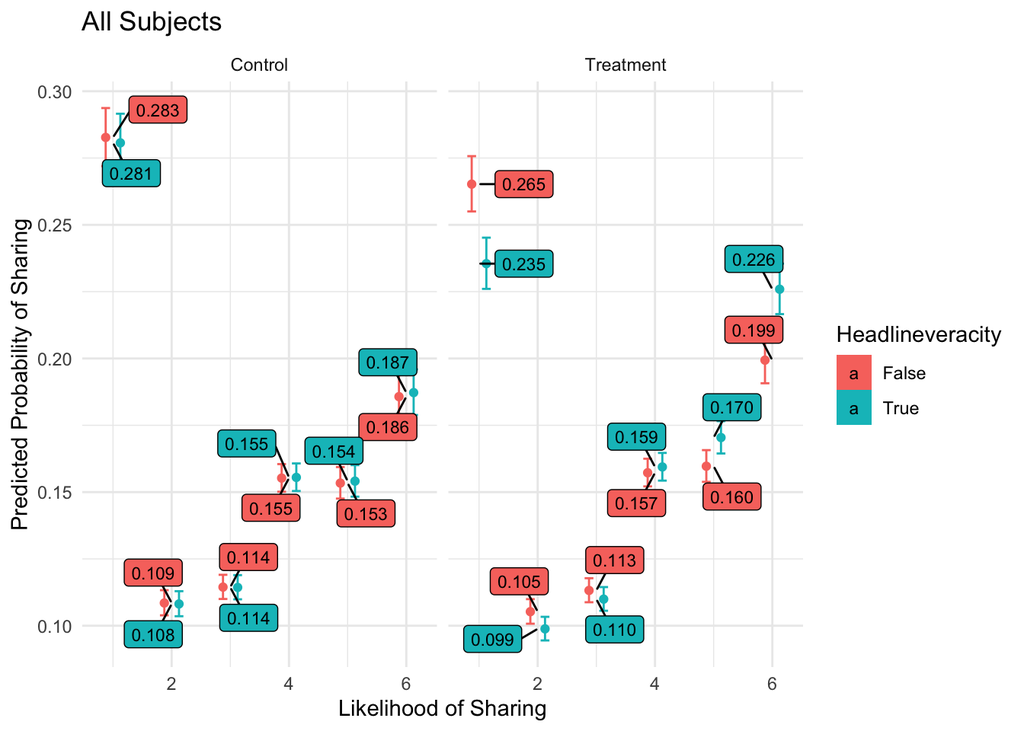

```r
ggplot(ggpredict_ordinaldata, aes(x = Rating, y = predicted)) +
  geom_point(aes(color = Headlineveracity), position =position_dodge(width = 0.5)) + geom_errorbar(aes(ymin = conf.low, ymax = conf.high, color = Headlineveracity), position = position_dodge(width = 0.5), width = 0.3) +
  theme_minimal() + facet_wrap(~group) + xlab("Likelihood of Sharing") + ylab("Predicted Probability of Sharing") +
  geom_label_repel(aes(label=sprintf("%.3f", predicted),fill = Headlineveracity), box.padding = 0.5, min.segment.length = unit(0, 'lines'), size = 3) + labs(title = "All Subjects")
```

```r
ggsave("All Subjects.png")



## attention check1

ordinaldata1 <- attention1nodi

str(ordinaldata1)
```

```
## 'data.frame':    24907 obs. of  11 variables:
##  $ ID              : int  1 1 1 1 1 1 1 1 1 1 ...
##  $ condition       : num  1 1 1 1 1 1 1 1 1 1 ...
##  $ newstype        : chr  "Fake1_1" "Fake1_2" "Fake1_3" "Fake1_4" ...
##  $ measurement     : num  5 5 6 6 5 5 5 5 4 5 ...
##  $ attentioncheck  : num  1 1 1 1 1 1 1 1 1 1 ...
##  $ Discern         : num  0.2 0.2 0.2 0.2 0.2 0.2 0.2 0.2 0.2 0.2 ...
##  $ Real            : num  5.33 5.33 5.33 5.33 5.33 ...
##  $ Fake            : num  5.13 5.13 5.13 5.13 5.13 ...
##  $ headlineveracity: chr  "0" "0" "0" "0" ...
##  $ rescale         : chr  "0.8" "0.8" "1" "1" ...
##  $ item_id         : num  1 2 3 4 5 6 7 8 9 10 ...
```

```r
ordinaldata1$measurement <- as.factor(ordinaldata1$measurement)


ordinal1 <- clm(measurement ~ condition + condition*headlineveracity, data = ordinaldata1, link = "logit")

summary(ordinal1)
```

```
## formula: measurement ~ condition + condition * headlineveracity
## data:    ordinaldata1
##
##  link  threshold nobs  logLik    AIC      niter max.grad cond.H
##  logit flexible  24907 -43363.91 86743.83 7(0)  4.48e-11 2.0e+02
##
## Coefficients:
##                             Estimate Std. Error z value Pr(>|z|)
## condition                   -0.01226    0.03201  -0.383  0.70184
## headlineveracity1            0.09915    0.03190   3.108  0.00188 **
## condition:headlineveracity1  0.14599    0.04477   3.261  0.00111 **
## ---
## Signif. codes:  0 '***' 0.001 '**' 0.01 '*' 0.05 '.' 0.1 ' ' 1
##
## Threshold coefficients:
##     Estimate Std. Error z value
## 1|2 -0.94084    0.02434 -38.648
## 2|3 -0.44760    0.02373 -18.861
## 3|4  0.02424    0.02358   1.028
## 4|5  0.67572    0.02395  28.216
## 5|6  1.49990    0.02559  58.603
```

```r
exp(coef(ordinal1))
```

```
##                         1|2                         2|3
##                   0.3902989                   0.6391573
##                         3|4                         4|5
##                   1.0245412                   1.9654560
##                         5|6                   condition
##                   4.4812291                   0.9878188
##           headlineveracity1 condition:headlineveracity1
##                   1.1042279                   1.1571862
```

```r
ggpredict_ordinal1 <- ggpredict(ordinal1, terms = c("condition","headlineveracity"))
ggpredict_ordinaldata1 = data.frame(ggpredict_ordinal1)

ggpredict_ordinal1
```

```
## # Predicted probabilities of measurement
##
## # Response Level = 1
## # headlineveracity = 0
##
## condition | Predicted |       95% CI
## ------------------------------------
##         0 |      0.28 | [0.27, 0.29]
##         1 |      0.28 | [0.27, 0.29]
##
## # Response Level = 2
## # headlineveracity = 0
##
## condition | Predicted |       95% CI
## ------------------------------------
##         0 |      0.11 | [0.10, 0.11]
##         1 |      0.11 | [0.10, 0.11]
##
## # Response Level = 3
## # headlineveracity = 0
##
## condition | Predicted |       95% CI
## ------------------------------------
##         0 |      0.12 | [0.11, 0.12]
##         1 |      0.12 | [0.11, 0.12]
##
## # Response Level = 4
## # headlineveracity = 0
##
## condition | Predicted |       95% CI
## ------------------------------------
##         0 |      0.16 | [0.15, 0.16]
##         1 |      0.16 | [0.15, 0.16]
##
## # Response Level = 5
## # headlineveracity = 0
##
## condition | Predicted |       95% CI
## ------------------------------------
##         0 |      0.15 | [0.15, 0.16]
```

[output cut: 42 more lines]

```
## # Response Level = 5
## # headlineveracity = 1
##
## condition | Predicted |       95% CI
## ------------------------------------
##         0 |      0.16 | [0.16, 0.17]
##         1 |      0.17 | [0.17, 0.18]
##
## # Response Level = 6
## # headlineveracity = 1
##
## condition | Predicted |       95% CI
## ------------------------------------
##         0 |      0.20 | [0.19, 0.21]
##         1 |      0.22 | [0.21, 0.23]
```

```r
str(ggpredict_ordinaldata1)
```

```
## 'data.frame':    24 obs. of  6 variables:
##  $ x             : num  0 0 0 0 0 0 0 0 0 0 ...
##  $ predicted     : num  0.281 0.109 0.116 0.157 0.155 ...
##  $ conf.low      : num  0.27 0.105 0.112 0.152 0.149 ...
##  $ conf.high     : num  0.292 0.114 0.121 0.162 0.161 ...
##  $ response.level: int  1 2 3 4 5 6 1 2 3 4 ...
##  $ group         : Factor w/ 2 levels "0","1": 1 1 1 1 1 1 2 2 2 2 ...
```

```r
ggpredict_ordinaldata1$x = factor(ggpredict_ordinaldata1$x)
levels(ggpredict_ordinaldata1$x) = c("False", "True")
colnames(ggpredict_ordinaldata1)[c(1,5,6)] =c("Headlineveracity", "Rating", "group")
levels(ggpredict_ordinaldata1$group) = c("Control", "Treatment")
ggpredict_ordinaldata1
```

```
##    Headlineveracity  predicted   conf.low conf.high Rating     group
## 1             False 0.28073021 0.26984536 0.2918786      1   Control
## 2             False 0.10920022 0.10450595 0.1140785      2   Control
## 3             False 0.11613050 0.11159139 0.1208291      3   Control
## 4             False 0.15672280 0.15152505 0.1620648      4   Control
## 5             False 0.15477543 0.14882287 0.1609211      5   Control
## 6             False 0.18244083 0.17403957 0.1911538      6   Control
## 7             False 0.26115215 0.25084861 0.2717254      1 Treatment
## 8             False 0.10546637 0.10088491 0.1102304      2 Treatment
## 9             False 0.11466487 0.11015507 0.1193345      3 Treatment
## 10            False 0.15899622 0.15379196 0.1643424      4 Treatment
## 11            False 0.16202343 0.15601968 0.1682122      5 Treatment
## 12            False 0.19769697 0.18894152 0.2067547      6 Treatment
## 13             True 0.28321157 0.27240103 0.2942776      1   Control
## 14             True 0.10963826 0.10494507 0.1145145      2   Control
## 15             True 0.11627437 0.11173269 0.1209755      3   Control
## 16             True 0.15639326 0.15120848 0.1617220      4   Control
## 17             True 0.15386264 0.14795605 0.1599608      5   Control
## 18             True 0.18061989 0.17233703 0.1892098      6   Control
## 19             True 0.23618247 0.22661435 0.2460261      1 Treatment
## 20             True 0.09997027 0.09555159 0.1045697      2 Treatment
## 21             True 0.11187643 0.10742696 0.1164861      3 Treatment
## 22             True 0.16090696 0.15569388 0.1662602      4 Treatment
## 23             True 0.17129531 0.16520649 0.1775608      5 Treatment
## 24             True 0.21976857 0.21050992 0.2293162      6 Treatment
```

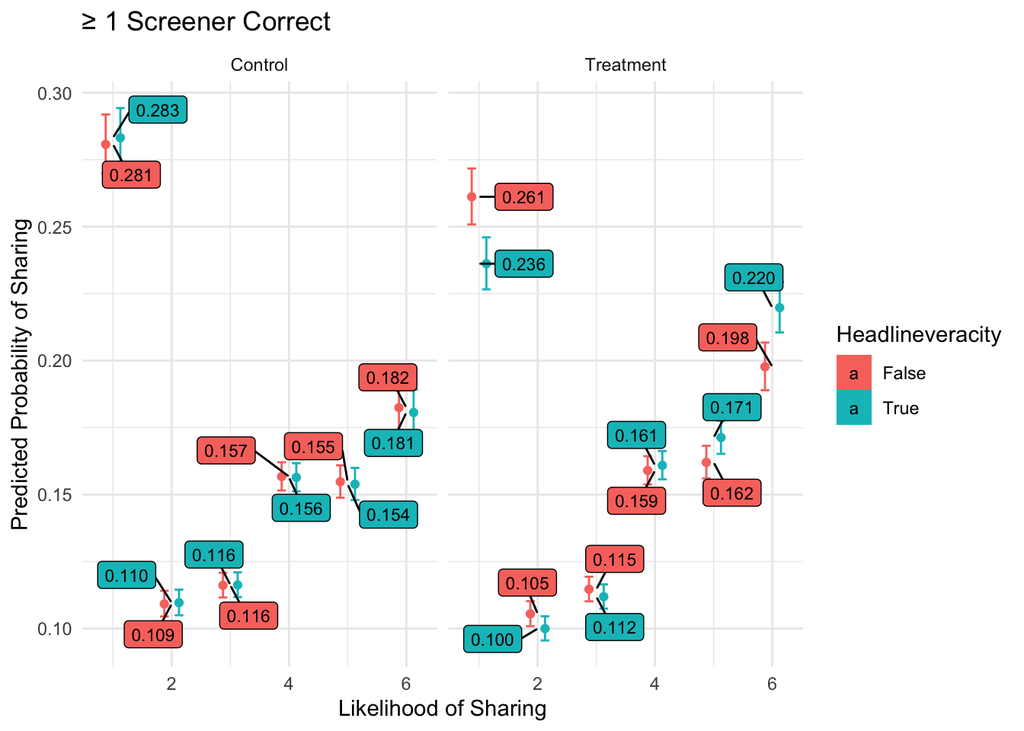

```r
ggplot(ggpredict_ordinaldata1, aes(x = Rating, y = predicted)) +
  geom_point(aes(color = Headlineveracity), position =position_dodge(width = 0.5)) + geom_errorbar(aes(ymin = conf.low, ymax = conf.high, color = Headlineveracity), position = position_dodge(width = 0.5), width = 0.3) +
  theme_minimal() + facet_wrap(~group) + xlab("Likelihood of Sharing") + ylab("Predicted Probability of Sharing") + geom_label_repel(aes(label=sprintf("%.3f", predicted),fill = Headlineveracity), box.padding = 0.5, min.segment.length = unit(0, 'lines'), size = 3) + labs(title = "\u2265 1 Screener Correct")
```

```r
ggsave("\u2265 1 Screener Correct.png")


##tips, \u2265 could display greater and equal to sign



## attention check2

ordinaldata2 <- attention2nodi

str(ordinaldata2)
```

```
## 'data.frame':    19335 obs. of  11 variables:
##  $ ID              : int  2 2 2 2 2 2 2 2 2 2 ...
##  $ condition       : num  0 0 0 0 0 0 0 0 0 0 ...
##  $ newstype        : chr  "Fake1_1" "Fake1_2" "Fake1_3" "Fake1_4" ...
##  $ measurement     : num  2 1 3 1 4 4 3 1 1 1 ...
##  $ attentioncheck  : num  2 2 2 2 2 2 2 2 2 2 ...
##  $ Discern         : num  0.667 0.667 0.667 0.667 0.667 ...
##  $ Real            : num  2.93 2.93 2.93 2.93 2.93 ...
##  $ Fake            : num  2.27 2.27 2.27 2.27 2.27 ...
##  $ headlineveracity: chr  "0" "0" "0" "0" ...
##  $ rescale         : chr  "0.2" "0" "0.4" "0" ...
##  $ item_id         : num  1 2 3 4 5 6 7 8 9 10 ...
```

```r
ordinaldata2$measurement <- as.factor(ordinaldata2$measurement)


ordinal2 <- clm(measurement ~ condition + condition*headlineveracity, data = ordinaldata2, link = "logit")

summary(ordinal2)
```

```
## formula: measurement ~ condition + condition * headlineveracity
## data:    ordinaldata2
##
##  link  threshold nobs  logLik    AIC      niter max.grad cond.H
##  logit flexible  19335 -33427.89 66871.79 7(0)  3.76e-11 2.0e+02
##
## Coefficients:
##                             Estimate Std. Error z value Pr(>|z|)
## condition                   -0.05881    0.03642  -1.615 0.106412
## headlineveracity1            0.12618    0.03585   3.520 0.000431 ***
## condition:headlineveracity1  0.19014    0.05091   3.735 0.000188 ***
## ---
## Signif. codes:  0 '***' 0.001 '**' 0.01 '*' 0.05 '.' 0.1 ' ' 1
##
## Threshold coefficients:
##     Estimate Std. Error z value
## 1|2 -0.80654    0.02712 -29.735
## 2|3 -0.30083    0.02657 -11.323
## 3|4  0.14559    0.02651   5.493
## 4|5  0.78320    0.02707  28.928
## 5|6  1.61152    0.02923  55.139
```

```r
exp(coef(ordinal2))
```

```
##                         1|2                         2|3
##                   0.4464009                   0.7402029
##                         3|4                         4|5
##                   1.1567236                   2.1884702
##                         5|6                   condition
##                   5.0103979                   0.9428885
##           headlineveracity1 condition:headlineveracity1
##                   1.1344918                   1.2094133
```

```r
ggpredict_ordinal2 <- ggpredict(ordinal2, terms = c("condition","headlineveracity"))
ggpredict_ordinaldata2 = data.frame(ggpredict_ordinal2)

ggpredict_ordinal2
```

```
## # Predicted probabilities of measurement
##
## # Response Level = 1
## # headlineveracity = 0
##
## condition | Predicted |       95% CI
## ------------------------------------
##         0 |      0.31 | [0.30, 0.32]
##         1 |      0.32 | [0.31, 0.33]
##
## # Response Level = 2
## # headlineveracity = 0
##
## condition | Predicted |       95% CI
## ------------------------------------
##         0 |      0.12 | [0.11, 0.12]
##         1 |      0.12 | [0.11, 0.12]
##
## # Response Level = 3
## # headlineveracity = 0
##
## condition | Predicted |       95% CI
## ------------------------------------
##         0 |      0.11 | [0.11, 0.12]
##         1 |      0.11 | [0.11, 0.12]
##
## # Response Level = 4
## # headlineveracity = 0
##
## condition | Predicted |       95% CI
## ------------------------------------
##         0 |      0.15 | [0.14, 0.16]
##         1 |      0.15 | [0.14, 0.15]
##
## # Response Level = 5
## # headlineveracity = 0
##
## condition | Predicted |       95% CI
## ------------------------------------
##         0 |      0.15 | [0.14, 0.15]
```

[output cut: 42 more lines]

```
## # Response Level = 5
## # headlineveracity = 1
##
## condition | Predicted |       95% CI
## ------------------------------------
##         0 |      0.16 | [0.15, 0.16]
##         1 |      0.17 | [0.16, 0.17]
##
## # Response Level = 6
## # headlineveracity = 1
##
## condition | Predicted |       95% CI
## ------------------------------------
##         0 |      0.18 | [0.18, 0.19]
##         1 |      0.21 | [0.20, 0.22]
```

```r
str(ggpredict_ordinaldata2)
```

```
## 'data.frame':    24 obs. of  6 variables:
##  $ x             : num  0 0 0 0 0 0 0 0 0 0 ...
##  $ predicted     : num  0.309 0.117 0.111 0.15 0.147 ...
##  $ conf.low      : num  0.296 0.111 0.106 0.144 0.141 ...
##  $ conf.high     : num  0.322 0.122 0.116 0.156 0.154 ...
##  $ response.level: int  1 2 3 4 5 6 1 2 3 4 ...
##  $ group         : Factor w/ 2 levels "0","1": 1 1 1 1 1 1 2 2 2 2 ...
```

```r
ggpredict_ordinaldata2$x = factor(ggpredict_ordinaldata2$x)
levels(ggpredict_ordinaldata2$x) = c("False", "True")
colnames(ggpredict_ordinaldata2)[c(1,5,6)] =c("Headlineveracity", "Rating", "group")
levels(ggpredict_ordinaldata2$group) = c("Control", "Treatment")
ggpredict_ordinaldata2
```

```
##    Headlineveracity predicted  conf.low conf.high Rating     group
## 1             False 0.3086287 0.2958095 0.3217497      1   Control
## 2             False 0.1167256 0.1113537 0.1223211      2   Control
## 3             False 0.1109794 0.1059852 0.1161783      3   Control
## 4             False 0.1500363 0.1441798 0.1560872      4   Control
## 5             False 0.1472517 0.1405873 0.1541754      5   Control
## 6             False 0.1663783 0.1574901 0.1756637      6   Control
## 7             False 0.2823727 0.2703091 0.2947571      1 Treatment
## 8             False 0.1124665 0.1072160 0.1179401      2 Treatment
## 9             False 0.1100124 0.1050405 0.1151893      3 Treatment
## 10            False 0.1537387 0.1478564 0.1598111      4 Treatment
## 11            False 0.1567862 0.1499898 0.1638312      5 Treatment
## 12            False 0.1846236 0.1751831 0.1944529      6 Treatment
## 13             True 0.3213160 0.3081232 0.3348003      1   Control
## 14             True 0.1184717 0.1130580 0.1241083      2   Control
## 15             True 0.1111348 0.1061375 0.1163368      3   Control
## 16             True 0.1479659 0.1421302 0.1539982      4   Control
## 17             True 0.1427305 0.1361353 0.1495897      5   Control
## 18             True 0.1583812 0.1497064 0.1674596      6   Control
## 19             True 0.2565361 0.2450538 0.2683652      1 Treatment
## 20             True 0.1073946 0.1022723 0.1127413      2 Treatment
## 21             True 0.1081181 0.1031881 0.1132539      3 Treatment
## 22             True 0.1564285 0.1505212 0.1625232      4 Treatment
## 23             True 0.1663059 0.1593282 0.1735262      5 Treatment
## 24             True 0.2052168 0.1950261 0.2157972      6 Treatment
```

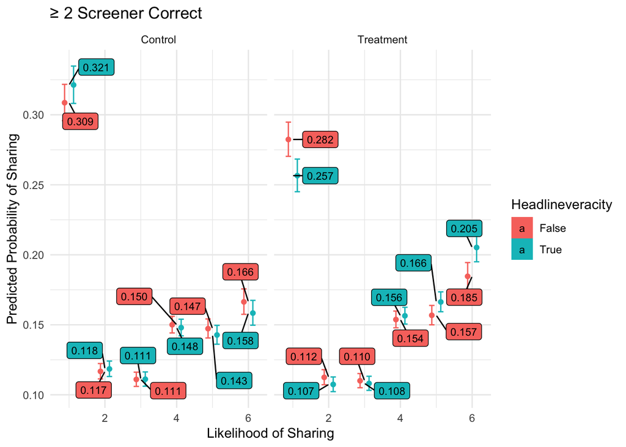

```r
ggplot(ggpredict_ordinaldata2, aes(x = Rating, y = predicted)) +
  geom_point(aes(color = Headlineveracity), position =position_dodge(width = 0.5)) + geom_errorbar(aes(ymin = conf.low, ymax = conf.high, color = Headlineveracity), position = position_dodge(width = 0.5), width = 0.3) +
  theme_minimal() + facet_wrap(~group) + xlab("Likelihood of Sharing") + ylab("Predicted Probability of Sharing") + geom_label_repel(aes(label=sprintf("%.3f", predicted),fill = Headlineveracity), box.padding = 0.5, min.segment.length = unit(0, 'lines'), size = 3) + labs(title = "\u2265 2 Screener Correct")
```

```r
ggsave("\u2265 2 Screener Correct.png")



## attention check 3

ordinaldata3 <- attention3nodi

str(ordinaldata3)
```

```
## 'data.frame':    6865 obs. of  11 variables:
##  $ ID              : int  5 5 5 5 5 5 5 5 5 5 ...
##  $ condition       : num  0 0 0 0 0 0 0 0 0 0 ...
##  $ newstype        : chr  "Fake1_1" "Fake1_2" "Fake1_3" "Fake1_4" ...
##  $ measurement     : num  5 5 5 4 5 5 5 5 4 5 ...
##  $ attentioncheck  : num  3 3 3 3 3 3 3 3 3 3 ...
##  $ Discern         : num  -0.2 -0.2 -0.2 -0.2 -0.2 -0.2 -0.2 -0.2 -0.2 -0.2 ...
##  $ Real            : num  4.73 4.73 4.73 4.73 4.73 ...
##  $ Fake            : num  4.93 4.93 4.93 4.93 4.93 ...
##  $ headlineveracity: chr  "0" "0" "0" "0" ...
##  $ rescale         : chr  "0.8" "0.8" "0.8" "0.6" ...
##  $ item_id         : num  1 2 3 4 5 6 7 8 9 10 ...
```

```r
ordinaldata3$measurement <- as.factor(ordinaldata3$measurement)


ordinal3 <- clm(measurement ~ condition + condition*headlineveracity, data = ordinaldata3, link = "logit")

summary(ordinal3)
```

```
## formula: measurement ~ condition + condition * headlineveracity
## data:    ordinaldata3
##
##  link  threshold nobs logLik    AIC      niter max.grad cond.H
##  logit flexible  6865 -11757.30 23530.60 5(1)  5.12e-10 2.2e+02
##
## Coefficients:
##                             Estimate Std. Error z value Pr(>|z|)
## condition                   -0.14706    0.06145  -2.393   0.0167 *
## headlineveracity1            0.10074    0.05989   1.682   0.0926 .
## condition:headlineveracity1  0.13809    0.08558   1.614   0.1066
## ---
## Signif. codes:  0 '***' 0.001 '**' 0.01 '*' 0.05 '.' 0.1 ' ' 1
##
## Threshold coefficients:
##      Estimate Std. Error z value
## 1|2 -0.850015   0.045567 -18.654
## 2|3 -0.396702   0.044695  -8.876
## 3|4  0.001691   0.044455   0.038
## 4|5  0.623775   0.045032  13.852
## 5|6  1.390766   0.047730  29.138
```

```r
exp(coef(ordinal3))
```

```
##                         1|2                         2|3
##                   0.4274087                   0.6725346
##                         3|4                         4|5
##                   1.0016928                   1.8659586
##                         5|6                   condition
##                   4.0179281                   0.8632405
##           headlineveracity1 condition:headlineveracity1
##                   1.1059917                   1.1480789
```

```r
ggpredict_ordinal3 <- ggpredict(ordinal3, terms = c("condition","headlineveracity"))
ggpredict_ordinaldata3 = data.frame(ggpredict_ordinal3)

ggpredict_ordinal3
```

```
## # Predicted probabilities of measurement
##
## # Response Level = 1
## # headlineveracity = 0
##
## condition | Predicted |       95% CI
## ------------------------------------
##         0 |      0.30 | [0.28, 0.32]
##         1 |      0.33 | [0.31, 0.35]
##
## # Response Level = 2
## # headlineveracity = 0
##
## condition | Predicted |       95% CI
## ------------------------------------
##         0 |      0.10 | [0.09, 0.11]
##         1 |      0.11 | [0.10, 0.12]
##
## # Response Level = 3
## # headlineveracity = 0
##
## condition | Predicted |       95% CI
## ------------------------------------
##         0 |      0.10 | [0.09, 0.11]
##         1 |      0.10 | [0.09, 0.11]
##
## # Response Level = 4
## # headlineveracity = 0
##
## condition | Predicted |       95% CI
## ------------------------------------
##         0 |      0.15 | [0.14, 0.16]
##         1 |      0.15 | [0.14, 0.16]
##
## # Response Level = 5
## # headlineveracity = 0
##
## condition | Predicted |       95% CI
## ------------------------------------
##         0 |      0.15 | [0.14, 0.16]
```

[output cut: 42 more lines]

```
## # Response Level = 5
## # headlineveracity = 1
##
## condition | Predicted |       95% CI
## ------------------------------------
##         0 |      0.16 | [0.15, 0.17]
##         1 |      0.16 | [0.14, 0.17]
##
## # Response Level = 6
## # headlineveracity = 1
##
## condition | Predicted |       95% CI
## ------------------------------------
##         0 |      0.22 | [0.20, 0.23]
##         1 |      0.21 | [0.20, 0.23]
```

```r
str(ggpredict_ordinaldata3)
```

```
## 'data.frame':    24 obs. of  6 variables:
##  $ x             : num  0 0 0 0 0 0 0 0 0 0 ...
##  $ predicted     : num  0.2994 0.1027 0.0983 0.1507 0.1496 ...
##  $ conf.low      : num  0.2785 0.0943 0.0905 0.141 0.1388 ...
##  $ conf.high     : num  0.321 0.112 0.107 0.161 0.161 ...
##  $ response.level: int  1 2 3 4 5 6 1 2 3 4 ...
##  $ group         : Factor w/ 2 levels "0","1": 1 1 1 1 1 1 2 2 2 2 ...
```

```r
ggpredict_ordinaldata3$x = factor(ggpredict_ordinaldata3$x)
levels(ggpredict_ordinaldata3$x) = c("False", "True")
colnames(ggpredict_ordinaldata3)[c(1,5,6)] =c("Headlineveracity", "Rating", "group")
levels(ggpredict_ordinaldata3$group) = c("Control", "Treatment")
ggpredict_ordinaldata3
```

```
##    Headlineveracity  predicted   conf.low conf.high Rating     group
## 1             False 0.29942979 0.27845279 0.3212834      1   Control
## 2             False 0.10267526 0.09434216 0.1116537      2   Control
## 3             False 0.09831778 0.09049564 0.1067367      3   Control
## 4             False 0.15065377 0.14104381 0.1607959      4   Control
## 5             False 0.14963796 0.13878133 0.1611849      5   Control
## 6             False 0.19928544 0.18276148 0.2169068      6   Control
## 7             False 0.27873261 0.25896860 0.2993956      1 Treatment
## 8             False 0.09940891 0.09127332 0.1081833      2 Treatment
## 9             False 0.09711595 0.08935244 0.1054759      3 Treatment
## 10            False 0.15259913 0.14297168 0.1627518      4 Treatment
## 11            False 0.15629465 0.14535943 0.1678909      5 Treatment
## 12            False 0.21584875 0.19872441 0.2340178      6 Treatment
## 13             True 0.33115791 0.30864690 0.3544690      1   Control
## 14             True 0.10675427 0.09824678 0.1159038      2   Control
## 15             True 0.09920772 0.09134990 0.1076614      3   Control
## 16             True 0.14658199 0.13703482 0.1566735      4   Control
## 17             True 0.13944691 0.12888488 0.1507247      5   Control
## 18             True 0.17685120 0.16130704 0.1935476      6   Control
## 19             True 0.28053992 0.26042677 0.3015730      1 Treatment
## 20             True 0.09971366 0.09157097 0.1084939      2 Treatment
## 21             True 0.09724188 0.08947144 0.1056089      3 Treatment
## 22             True 0.15245506 0.14283688 0.1625980      4 Treatment
## 23             True 0.15571545 0.14479287 0.1673008      5 Treatment
## 24             True 0.21433405 0.19700561 0.2327449      6 Treatment
```

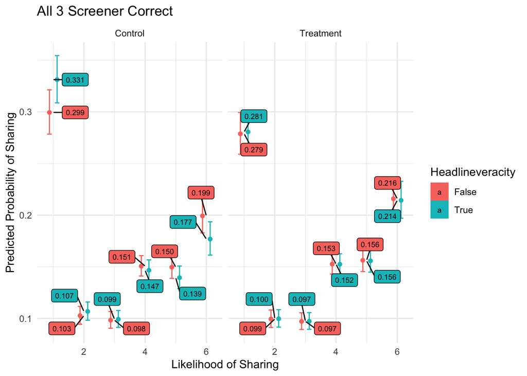

```r
ggplot(ggpredict_ordinaldata3, aes(x = Rating, y = predicted)) +
  geom_point(aes(color = Headlineveracity), position =position_dodge(width = 0.5)) + geom_errorbar(aes(ymin = conf.low, ymax = conf.high, color = Headlineveracity), position = position_dodge(width = 0.5), width = 0.3) +
  theme_minimal() + facet_wrap(~group) + xlab("Likelihood of Sharing") + ylab("Predicted Probability of Sharing") + geom_label_repel(aes(label=sprintf("%.3f", predicted),fill = Headlineveracity), box.padding = 0.55, min.segment.length = unit(0, 'lines'), size = 2.5) + labs(title = "All 3 Screener Correct")
```

```r
ggsave("All 3 Screener Correct.png")
```

### code testing (irrelevant)

###GLM (bad idea, because it dicotomize the results leads to loss information and verlidity)

## use glm, stepwise approach to see how each factor explaining the sharing intention. The family for the model is binomial since the dependent variable is dichotomous.

glm0 <- glm(measurement ~ 1, data = pennys2r1long_nona, family = binomial(link = “logit”))

glm1 <- glm(measurement ~ condition, data = pennys2r1long_nona, family = binomial(link = “logit”))

glm2 <- glm(measurement ~ condition + headlineveracity, data = pennys2r1long_nona, family = binomial(link = “logit”))

glm3 <- glm(measurement ~ condition + condition*headlineveracity, data = pennys2r1long_nona, family = binomial(link = “logit”))

glm4 <- glm(measurement ~ condition + headlineveracity + attentioncheck, data = pennys2r1long_nona, family = binomial(link = “logit”))

glm5 <- glm(measurement ~ condition + condition*headlineveracity + attentioncheck, data = pennys2r1long_nona, family = binomial(link = “logit”))

anova(glm0,glm1,glm2,glm3,glm4,test=‘LR’)

##looking at summary glm4, it is cleat that condition does not have a significant effect on measurement summary(glm5)

###odds ratios and 95% CI

exp(cbind(OR = coef(glm3), confint(glm3)))

##subset the attention based on attention check attention1 <- subset(pennys2r1long_nona, attentioncheck %in% c(“1”,“2”,“3”)) attention2 <- subset(pennys2r1long_nona, attentioncheck %in% c(“2”,“3”)) attention3 <- subset(pennys2r1long_nona, attentioncheck %in% c(“3”))

## Different attention check group

glm41 <- glm(measurement ~ condition + headlineveracity + attentioncheck, data = attention1, family = binomial(link = “logit”)) glm411 <- glm(measurement ~ condition + condition*headlineveracity, data = attention1, family = binomial(link = “logit”))

summary(glm41) summary(glm411)

glm42 <- glm(measurement ~ condition + headlineveracity + attentioncheck, data = attention2, family = binomial(link = “logit”)) glm421 <- glm(measurement ~ condition + condition*headlineveracity + attentioncheck, data = attention2, family = binomial(link = “logit”))

summary(glm42) summary(glm421)

glm43 <- glm(measurement ~ condition + headlineveracity, data = attention3, family = binomial(link = “logit”)) glm431 <- glm(measurement ~ condition + condition*headlineveracity, data = attention3, family = binomial(link = “logit”))

summary(glm43) summary(glm431)

```
#old graph



#Find out the sum for each type of news in different condition

p1 <- aggregate(measurement~condition+headlineveracity, data = pennys2r1long_nona, na.rm = TRUE, FUN = sum)



#since the obs is 25,627, thus for each news in each condition, it observed 25,627/4 = 6406.75
p1 <- transform(p1, percent = ave(measurement, condition, FUN = function(x) paste0(round(x/6406.75, 4)*100)))

#plot the graph

ggplot(p1, aes(x = factor(condition), y = as.numeric(percent), fill = headlineveracity)) +
  geom_bar(stat = 'identity',position = 'dodge') +
  geom_text(
    aes(label = as.numeric (percent)), vjust = 1.5, position = position_dodge(0.9)) +
  xlab("Condition") +
  ylab("Likelihood of Sharing (%)") +
  scale_x_discrete(labels= c("0"="Control","1"="Treatment"))+
  scale_fill_discrete(name = "Headline Veracity", labels = c("False", "True")) + labs(title = "All Subjects")
```

#z scored scale(pennystudy2r1$D)

#Additional ##maybe a mixed effect models?

###create a new column that recode item number from fake and real to 1-30, with 1-15 indicate each fake items, 16-30 indicate each real items

pennys2r1long <- within(pennys2r1long,{ item_id <- NA item_id[newstype == “Fake1_1”] <- 1 item_id[newstype == “Fake1_2”] <- 2 item_id[newstype == “Fake1_3”] <- 3 item_id[newstype == “Fake1_4”] <- 4 item_id[newstype == “Fake1_5”] <- 5 item_id[newstype == “Fake1_6”] <- 6 item_id[newstype == “Fake1_7”] <- 7 item_id[newstype == “Fake1_8”] <- 8 item_id[newstype == “Fake1_9”] <- 9 item_id[newstype == “Fake1_10”] <- 10 item_id[newstype == “Fake1_11”] <- 11 item_id[newstype == “Fake1_12”] <- 12 item_id[newstype == “Fake1_13”] <- 13 item_id[newstype == “Fake1_14”] <- 14 item_id[newstype == “Fake1_15”] <- 15 item_id[newstype == “Real1_1”] <- 16 item_id[newstype == “Real1_2”] <- 17 item_id[newstype == “Real1_3”] <- 18 item_id[newstype == “Real1_4”] <- 19 item_id[newstype == “Real1_5”] <- 20 item_id[newstype == “Real1_6”] <- 21 item_id[newstype == “Real1_7”] <- 22 item_id[newstype == “Real1_8”] <- 23 item_id[newstype == “Real1_9”] <- 24 item_id[newstype == “Real1_10”] <- 25 item_id[newstype == “Real1_11”] <- 26 item_id[newstype == “Real1_12”] <- 27 item_id[newstype == “Real1_13”] <- 28 item_id[newstype == “Real1_14”] <- 29 item_id[newstype == “Real1_15”] <- 30 })

library(lme4) library(lmerTest)

#model 1, item_id indicates repeated measurements for each item mult1 <- lmer (measurement ~ condition + condition*headlineveracity + (1|item_id), data = pennys2r1longnodi_nona) summary(mult1)

### graph 2 attention check above and equal to 1

#condition 2: above and equal to 1

pennystudy2plot2 <- pennys2r1longa1 %>% select (c(1, 2, 3, 4))

#separating the sheet

pennystudy2plot2c <- subset(pennystudy2plot2, condition %in% c(“0”)) pennystudy2plot2t <- subset(pennystudy2plot2, condition %in% c(“1”))

#Find out the sum for each type of news in different condition p2 <- aggregate(measurement~condition+newstype, data = pennystudy2plot2, FUN = sum)

##double check for correctness sum(pennystudy2plot2$measurement,na.rm = TRUE)

#since the obs is 1664, thus 1664/2 = 832 participants. So to get percentage of sharing intention each fake and real news need to divided by 832/2 = 416 ggplot(p2, aes(x = condition, y = measurement/428, fill = newstype)) + geom_bar(stat = ‘identity’,position = ‘dodge’) + geom_text( aes(label = round(measurement/428, digits = 3)), vjust = 1.5, position = position_dodge(0.9))+ scale_y_continuous(labels = scales::percent)

```
### graph 3 attention check above and equal to 2

#condition 3: above and equal to 2
pennystudy2plot3 <- pennys2r1longa2 %>%
  select (c(1, 2, 3, 4))


#Find out the sum for each type of news in different condition

p3 <- aggregate(measurement~condition+newstype, data = pennystudy2plot3, na.rm = TRUE, FUN = sum)
p3 <- transform(p3, percent = ave(measurement, condition, FUN = function(x) paste0(round(x/428, 4)*100)))


##double check for correctness
sum(pennystudy2plot3$measurement,na.rm = TRUE)

#plot the graph under the proportion of overall observation (856)
ggplot(p3, aes(x = condition, y = as.numeric(percent), fill = newstype)) +
  geom_bar(stat = 'identity',position = 'dodge') +
  geom_text(
    aes(label = as.numeric (percent)), vjust = 1.5, position = position_dodge(0.9))
```

### graph 3 attention check above and equal to 2: mean

#condition 3: above and equal to 2 pennystudy2plot3 <- pennys2r1longa2 %>% select (c(1, 2, 3, 4))

pennystudy2plot3c <- subset(pennystudy2plot3, condition %in% c(“0”)) pennystudy2plot3t <- subset(pennystudy2plot3, condition %in% c(“1”))

#Find out the sum and percentage for each type of news in each condition

##control, percentage = 658/2 = 329 p31 <- aggregate(measurement~condition+newstype, data = pennystudy2plot3c, na.rm = TRUE, FUN = sum) p31 <- transform(p31, percent = ave(measurement, condition, FUN = function(x) paste0(round(x/329, 4)*100)))

##treatment, percentage = 634/2 = 317 p32 <- aggregate(measurement~condition+newstype, data = pennystudy2plot3t, na.rm = TRUE, FUN = sum) p32 <- transform(p32, percent = ave(measurement, condition, FUN = function(x) paste0(round(x/317, 4)*100)))

#merge two table together under same column name p3 <- rbind(p31,p32)

##double check for correctness sum(pennystudy2plot3$measurement,na.rm = TRUE)

#plot the graph ggplot(p3, aes(x = condition, y = as.numeric(percent), fill = newstype)) + geom_bar(stat = ‘identity’,position = ‘dodge’) + geom_text( aes(label = as.numeric (percent)), vjust = 1.5, position = position_dodge(0.9))

```
### graph 4 attention check equal to 3

#condition 3: equal to 3
pennystudy2plot4 <- pennys2r1longa3 %>%
  select (c(1, 2, 3, 4))

#Find out the sum for each type of news in different condition
p4 <- aggregate(measurement~condition+newstype, data = pennystudy2plot4, FUN = sum)

##double check
sum(pennystudy2plot4$measurement,na.rm = TRUE)

#since the obs is 460 for attention = 3, thus 460/2 = 230 participants. So to get percentage of sharing intention each fake and real news need to divided by 230/2 = 115
ggplot(p4, aes(x = condition, y = measurement/115, fill = newstype)) +
  geom_bar(stat = 'identity',position = 'dodge') +
  geom_text(
    aes(label = round(measurement/115, digits = 3)), vjust = 1.5, position = position_dodge(0.9))+
    scale_y_continuous(labels = scales::percent)
```